# Advanced R Programming Techniques (`OPTIONAL`)

## Writing Functions and Loops for Automating Tasks

In advanced R programming, writing functions and loops efficiently is crucial for automating repetitive tasks and handling complex data operations.

### Function Arguments and Return Values

- **Function Arguments**: Functions can take multiple arguments, including default values, to make them more flexible and reusable.
- **Return Values**: Functions can return a single value or multiple values as a list.

**Example**:

```r
# Define a function with arguments and return value
my_function <- function(x, y = 2) {
  result <- x * y
  return(result)
}

# Call the function
my_function(5)    # Uses default value for y
```

```
## [1] 10
```

```r
my_function(5, 3) # Uses provided value for y
```

```
## [1] 15
```

### Looping Constructs: `for`, `while`, and `apply` Family

- **`for` Loop**: Iterates over a sequence of elements.
- **`while` Loop**: Continues to execute as long as a condition is true.
- **`apply` Family**: Functions like `lapply`, `sapply`, `tapply`, and `mapply` apply a function over elements of a list or vector, offering more concise and often faster alternatives to loops.

**Example**:

```r
# for loop example
for (i in 1:5) {
  print(i)
}
```

```
## [1] 1
## [1] 2
## [1] 3
## [1] 4
## [1] 5
```

```r
# while loop example
i <- 1
while (i <= 5) {
  print(i)
  i <- i + 1
}
```

```
## [1] 1
## [1] 2
## [1] 3
## [1] 4
## [1] 5
```

```r
# apply family example
vec <- 1:5
squared <- sapply(vec, function(x) x^2)
print(squared)
```

```
## [1]  1  4  9 16 25
```

### Avoiding Loops: Vectorization and Parallel Processing

- **Vectorization**: Writing code that operates on entire vectors or matrices at once, which is usually faster and more efficient than using loops.
- **Parallel Processing**: Using multiple cores or processors to perform computations simultaneously, which can significantly speed up data processing tasks.

**Example**:

```r
# Vectorized operation
vec <- 1:5
squared_vec <- vec^2
print(squared_vec)
```

```
## [1]  1  4  9 16 25
```

```r
# Parallel processing example using `parallel` package
library(parallel)
cl <- makeCluster(detectCores() - 1)
parSapply(cl, 1:5, function(x) x^2)
```

```
## [1]  1  4  9 16 25
```

```r
stopCluster(cl)
```

## Comprehensive Exercise: Automating Data Analysis with Functions and Loops

### Exercise: Automating Data Analysis with the `iris` Dataset

**Objective**: Write functions and use loops to automate the process of summarizing and analyzing the `iris` dataset. The exercise will include calculating summary statistics, visualizing data, and applying a machine learning model.

**Steps**: 1. **Write a function to calculate summary statistics for each species**. 2. **Use a loop to generate boxplots for each variable by species**. 3. **Write a function to train a decision tree model and evaluate its accuracy**. 4. **Combine these tasks into a comprehensive script that automates the entire process**.

### Detailed Steps

```
##
## Summary statistics for setosa :
##   Sepal.Length_mean Sepal.Length_sd Sepal.Width_mean Sepal.Width_sd
## 1             5.006       0.3524897            3.428      0.3790644
##   Petal.Length_mean Petal.Length_sd Petal.Width_mean Petal.Width_sd
## 1             1.462        0.173664            0.246      0.1053856
##
## Summary statistics for versicolor :
##   Sepal.Length_mean Sepal.Length_sd Sepal.Width_mean Sepal.Width_sd
## 1             5.936       0.5161711             2.77      0.3137983
##   Petal.Length_mean Petal.Length_sd Petal.Width_mean Petal.Width_sd
## 1              4.26        0.469911            1.326      0.1977527
##
## Summary statistics for virginica :
##   Sepal.Length_mean Sepal.Length_sd Sepal.Width_mean Sepal.Width_sd
## 1             6.588       0.6358796            2.974      0.3224966
##   Petal.Length_mean Petal.Length_sd Petal.Width_mean Petal.Width_sd
## 1             5.552       0.5518947            2.026      0.2746501
```

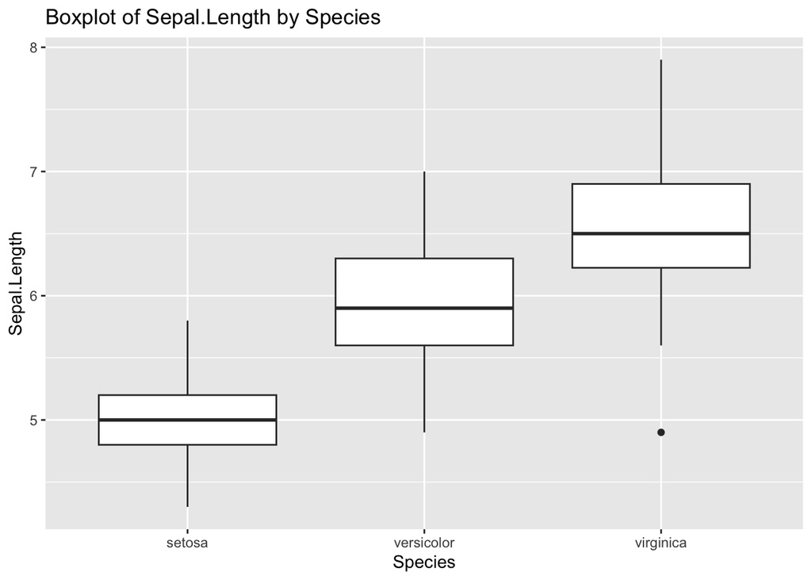

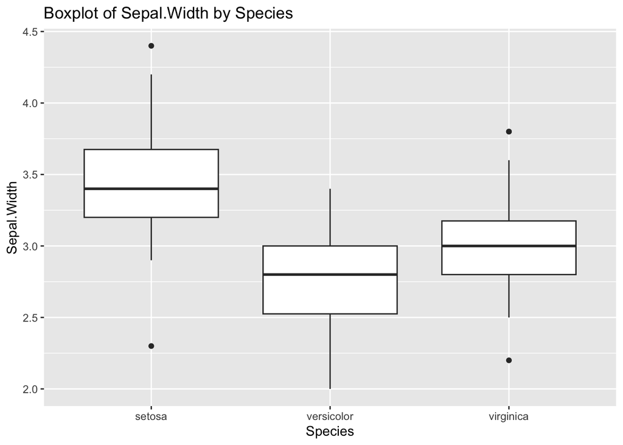

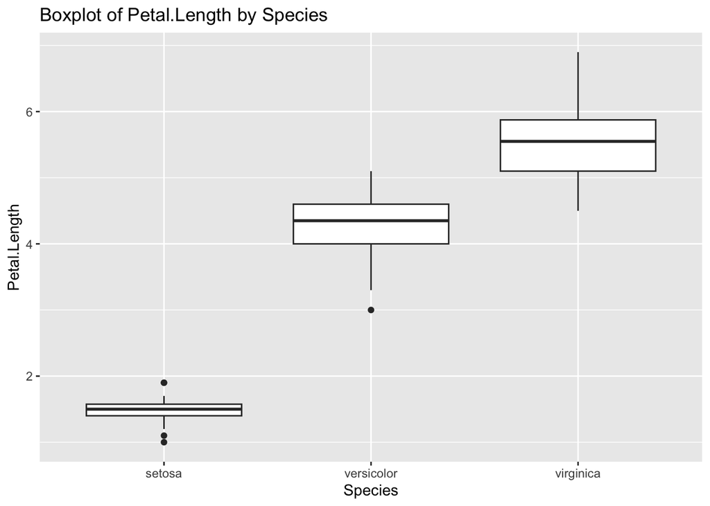

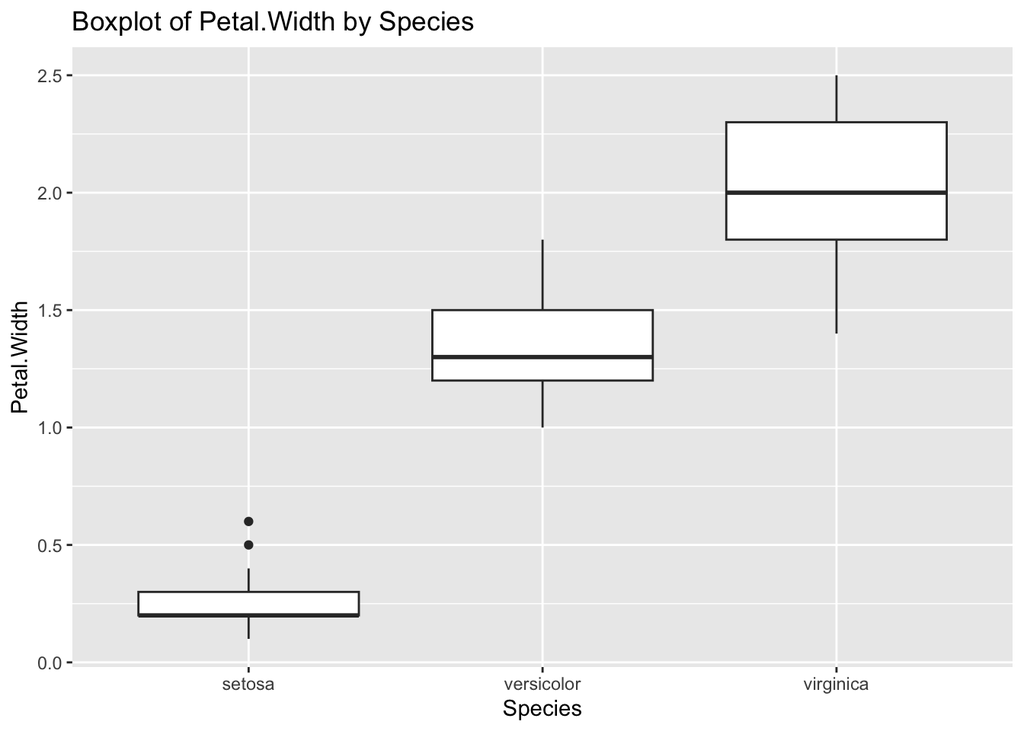

```
##
## Decision tree model accuracy: 0.9333333
```

```r
# Load necessary libraries
library(ggplot2)
library(caret)
library(rpart)
library(dplyr)
# 1. Function to calculate summary statistics for each species
summary_stats <- function(data, species) {
  data %>%
    filter(Species == species) %>%
    summarise(across(where(is.numeric), list(mean = mean, sd = sd)))
}

# 2. Loop to generate boxplots for each variable by species
plot_boxplots <- function(data) {
  variables <- colnames(data)[1:4]
  for (var in variables) {
    p <- ggplot(data, aes_string(x = "Species", y = var)) +
      geom_boxplot() +
      ggtitle(paste("Boxplot of", var, "by Species"))
    print(p)
  }
}

# 3. Function to train a decision tree model and evaluate its accuracy
train_decision_tree <- function(data) {
  set.seed(123)
  train_index <- createDataPartition(data$Species, p = 0.8, list = FALSE)
  train_data <- data[train_index, ]
  test_data <- data[-train_index, ]

  model <- rpart(Species ~ ., data = train_data, method = "class")
  predictions <- predict(model, test_data, type = "class")
  accuracy <- confusionMatrix(predictions, test_data$Species)$overall['Accuracy']

  return(accuracy)
}

# 4. Comprehensive script
iris_analysis <- function() {
  data <- iris

  # Calculate summary statistics for each species
  species <- unique(data$Species)
  for (sp in species) {
    cat("\nSummary statistics for", sp, ":\n")
    print(summary_stats(data, sp))
  }

  # Generate boxplots
  plot_boxplots(data)

  # Train decision tree model and evaluate accuracy
  accuracy <- train_decision_tree(data)
  cat("\nDecision tree model accuracy:", accuracy, "\n")
}

# Run the comprehensive analysis
iris_analysis()
```